# Informe de proyecto: Algoritmo de clasificación

Ricard Trinchet Arnejo

Enero 2019

# Clasificación

```r
library(corrplot)
library(rpart)
library("rpart.plot")
```

## Objetivo

El objetivo es explicar que clientes producen un mayor beneficio al negocio (para cuidarlos y ofrecerles ventajas exclusivas) y que clientes producen un menor beneficio para potenciar su consumo.

## Preparación de los datos

Primeramente, modificamos el juego de datos para obtener toda la información posible para entrenar al algoritmo.

```r
# clientes particulares únicos con información que puede ser relevante para el objetivo

beneficio_clientes <- cl_prod %>%
  group_by(cod.cliente) %>%
  mutate (beneficio = sum(beneficio), unidades.media = mean(total.unidades),
          suma.importe = sum(importe.total), importe.medio = mean(importe.total),
          ano.nacimiento = year(fecha.nacimiento), n.formas.pago = n_distinct(forma.pago)) %>%
  as.data.frame() %>%
  select(nombre.cliente, sexo, nacionalidad, ano.nacimiento, numero.hijos, nombre.tienda.y, total.compras,
         puntos.acumulados, unidades.media, suma.importe, importe.medio, n.formas.pago, beneficio) %>%
  unique() %>%
  filter(sexo != 'Empresa')

# eliminamos los nombres de los clientes

beneficio_clientes <- beneficio_clientes %>% select(-nombre.cliente)
```

Factorizamos la variable `beneficio` en 3 niveles: alto, medio y bajo. El objetivo del árbol de decisión será determinar en qué nivel se encuentra cada cliente basándonos en diversos factores.

La división se realiza del siguiente modo: a los clientes que suponen un beneficio menor de 50, se les asocia la etiqueta bajo, a los que suponen un beneficio mayor de 200, la etiqueta alto. Al resto, la etiqueta medio.

En la gráfica siguiente, observamos el número de clientes de la muestra que están en cada una de las categorías.

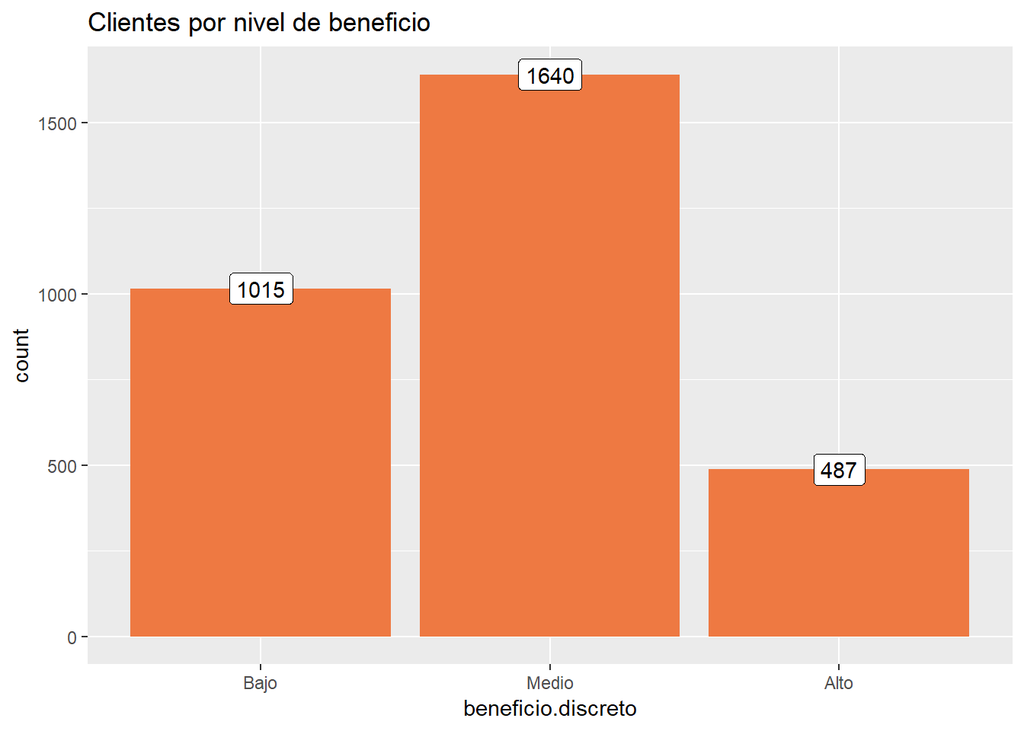

```r
#factorizamos la variable beneficio : bajo, medio, alto --------------

beneficio_clientes$beneficio.discreto <- cut(beneficio_clientes$beneficio, breaks = c(0,50,200, 1000), labels= c('Bajo', 'Medio', 'Alto'))

beneficio_clientes %>% group_by(beneficio.discreto) %>%
  summarise(count = length(beneficio.discreto)) %>%
  ggplot(aes(x=beneficio.discreto, y=count)) +
  geom_bar(stat="identity", fill="sienna2", show.legend=FALSE) +
  geom_label(aes(label=count)) +
  labs(title="Clientes por nivel de beneficio")
```

Hay una relación aproximada de 2-3-1 (es decir, por cada cliente en el grupo alto hay 2 en bajo y 3 en normal).

Mostramos la matriz de correlación para las variables numéricas del juego de datos.

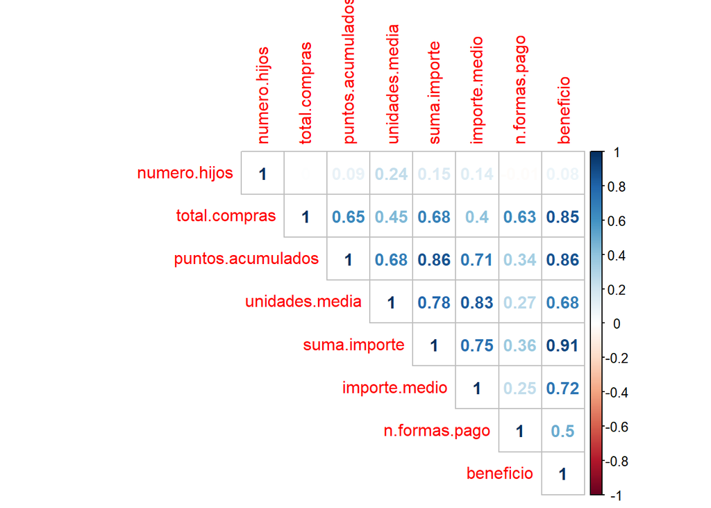

```r
## correlation matrix --------------


#correlation matrix
beneficio_clientes %>% select(-c(sexo, nacionalidad, ano.nacimiento, nombre.tienda.y, beneficio.discreto))  %>% cor() %>% corrplot( type="upper", method="number", tl.cex=1)
```

Observamos una gran correlación entre la variable `beneficio` y las variables `puntos.acumulados`, `suma.importe`, `unidades.media`, `importe.medio` y `total.compras`.

Debido a las relaciones existentes entre dichas variables, decidimos usar solamente las variables `puntos.acumulados`, `importe.medio` y `total.compras` para la construcción del arbol.

A continuación, visualizamos los clientes en función a su número de compras, los puntos que han acumulado y el importe medio que han gastado por compra. Les asignamos un color en base al beneficio que han supuesto para la empresa.

```r
### visualizacion 3d ----
# clientes-- compras, puntos, importe medio--- en base al beneficio
library(plotly)
plot_ly(beneficio_clientes, x=beneficio_clientes$total.compras, y=beneficio_clientes$importe.medio, z=beneficio_clientes$puntos.acumulados, type="scatter3d", mode="markers", color=beneficio_clientes$beneficio.discreto)
```

[output not shown]

Seguidamente, creamos los conjuntos de entrenamiento y test para la creación y validación del modelo.

```r
#### Conjuntos train y test---------

#fijamos una semilla para que el experimento sea reproducible
set.seed(123)

# Queremos "desordenar" los datos
bc_random <- beneficio_clientes[sample(nrow(beneficio_clientes)),]

head(bc_random)
```

|  | sexo | nacionalidad | ano.nacimiento | numero.hijos | nombre.tienda.y | total.compras | puntos.acumulados | unidades.media | suma.importe | importe.medio | n.formas.pago | beneficio | beneficio.discreto |
| --- | --- | --- | --- | --- | --- | --- | --- | --- | --- | --- | --- | --- | --- |
| 904 | Hombre | Reino Unido | 1963 | 2 | Londres I | 5 | 8 | 4.473684 | 854.4250 | 44.96974 | 3 | 61.44 | Medio |
| 2477 | Hombre | Estados Unidos | 1975 | 0 | Miami Beach | 5 | 10 | 5.375000 | 950.5250 | 59.40781 | 2 | 77.71 | Medio |
| 1285 | Hombre | Reino Unido | 1965 | 0 | Liverpool | 5 | 9 | 1.333333 | 76.9875 | 12.83125 | 3 | 24.97 | Bajo |
| 2772 | Mujer | España | 1975 | 0 | Barcelona | 4 | 8 | 1.500000 | 72.0900 | 18.02250 | 2 | 26.39 | Bajo |
| 2952 | Hombre | España | 1938 | 2 | Milán | 5 | 8 | 1.571429 | 130.8900 | 18.69857 | 3 | 42.22 | Bajo |
| 143 | Hombre | Reino Unido | 1941 | 2 | Londres II | 6 | 8 | 2.750000 | 509.8200 | 31.86375 | 2 | 72.14 | Medio |

```r
#str(bc_random)

y <- bc_random[,13] # beneficio discretizado
X <- bc_random[,1:11]

set.seed(123)
indexes = sample(1:nrow(beneficio_clientes), size=floor((2/3)*nrow(beneficio_clientes)))
train <- bc_random[indexes,]
trainX <- X[indexes,]
trainy <- y[indexes]
testX <- X[-indexes,]
testy <- y[-indexes]


# verificamos que los datos del conjunto de train y de test no están demasiado sesgados
table(trainy)
```

```
## trainy
##  Bajo Medio  Alto
##   683  1104   307
```

```r
table(testy)
```

```
## testy
##  Bajo Medio  Alto
##   332   536   180
```

La salida anterior nos sirve para verificar que los conjuntos de datos de train y test están homogéneamente distribuidos con respecto a los grupos de beneficio aportado. Es decir, que ambos grupos respetan la relación 2-3-1 que mencionamos anteriormente. Por tanto, podemos usar estos conjuntos para entrenar y verificar la eficacia del algoritmo.

## Construcción y validación del algoritmo

Construiremos un árbol de decisión, usando para ello el paquete `rpart` (https://cran.r-project.org/web/packages/rpart/rpart.pdf)

Creamos el arbol de decisión y lo mostramos en pantalla.

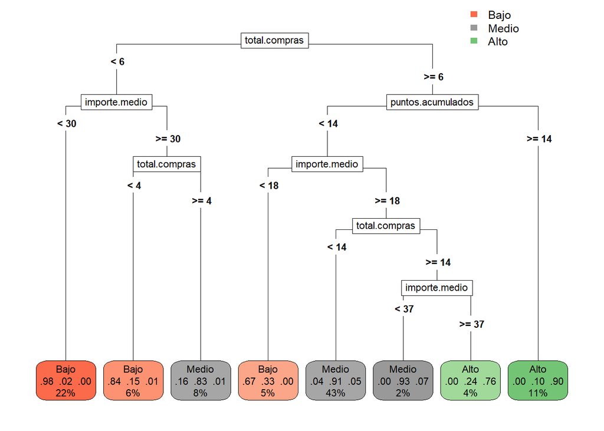

```r
bc_tree <- rpart(beneficio.discreto ~ total.compras + puntos.acumulados  +
                   importe.medio, data=train,
                 control = rpart.control(cp=0.02))
rpart.plot(bc_tree, box.palette = "auto", type= 5)
```

A continuación, obtenemos diversas medidas que nos permitirán determinar la precisión del modelo.

En primer lugar, la precisión del árbol y, en segundo lugar, la matriz de confusión.

```r
# precision del arbol ----
predicted_model2 <- predict( bc_tree, testX, type="class" )
print(sprintf("La precisión del árbol es del %.4f %%",100*sum(predicted_model2 == testy) / length(predicted_model2)))
```

```
## [1] "La precisión del árbol es del 88.3588 %"
```

```r
# matriz de confusion
mat_conf2 <- table(testy,Predicted=predicted_model2)
mat_conf2
```

```
##        Predicted
## testy   Bajo Medio Alto
##   Bajo   300    32    0
##   Medio   42   467   27
##   Alto     0    21  159
```

Se obtiene un buen valor de muestras clasificadas correctamente para el conjunto test (más del 88%).

Por otro lado, en la matriz de confusión, se aprecia como la mayor parte de los datos son correctamente clasificados en los grupos que les corresponden.

## Sugerencias para el negocio

A raíz del arbol de decisión obtenido, somos capaces de determinar que clientes aportan un beneficio alto al negocio: aquellos que realizan 6 o más compras, y acumulan 14 o más puntos.

Por otro lado, sabemos que los clientes que aportan un beneficio menor, realizan menos de 6 compras y gastan de media menos de 30.

Utilizando estos datos, podríamos sugerir que a los clientes que aporten un beneficio más bajo, se intente que aumenten su número de compras o los puntos que acumulan. No obstante, para efectuar una sugerencia más precisa, sería necesario hablar más en profundidad con el cliente y conocer qué tipo de esfuerzos de marketing estaría dispuesto a asumir.